# HW4

Burak Can Helvacı

## Task : Multiple Instance Learning

Suggest two alternative bag-level representations for the given multiple instance learning problem. Based on the proposed bag-level representations for Musk1 dataset, evaluate at least two reasonable classifiers (of your choice). Specify the best set of parameter combination for the proposed representations and your classifier. Use the accuracy based on 10-fold cross-validation on the training data as your primary performance metric in your evaluations.

Alternative Representations: *Euclidian Distance* Principal Component Analysis

Alternative Classifiers *Random Forest* Gradient Boosting

```r
library(data.table)
library(caret)
library(ranger)
library(gbm)

musk <- read.csv("Musk1.csv", header = FALSE)
dim(musk)
```

```
## [1] 476 168
```

```r
head(musk)
```

```
##   V1 V2 V3   V4   V5  V6   V7 V8 V9  V10 V11 V12  V13  V14  V15  V16  V17  V18 V19  V20  V21  V22 V23 V24 V25 V26 V27 V28 V29  V30 V31 V32  V33  V34
## 1  1  1 42 -198 -109 -75 -117 11 23  -88 -28 -27 -232 -212  -66 -286 -287 -300 -57  -75 -192 -184 -66 -18 -50 111 110  18 -18 -127  25  63 -117 -114
## 2  1  1 42 -191 -142 -65 -117 55 49 -170 -45   5 -325 -115 -107 -281 -257 -303  54 -154 -101  -47 -31 -28   1 191  72 -38  50  -64 -63  98 -117 -113
## 3  1  1 42 -191 -142 -75 -117 11 49 -161 -45 -28 -278 -115  -67 -274 -285 -303  53 -154 -100 -183 -31 -28   1 110 110 -38  51  -64  25  63 -117 -113
## 4  1  1 42 -198 -110 -65 -117 55 23  -95 -28   5 -301 -212 -107 -280 -284 -301 -56  -74 -192  -46 -66 -19 -50 191  73  18 -19 -128 -63  98 -117 -113
## 5  1  2 42 -198 -102 -75 -117 10 24  -87 -28 -28 -233 -212  -67 -286 -286 -299 -57  -74 -191 -182 -66 -18 -50 109 111  18 -18 -128  25  63 -117   55
##   V35 V36  V37 V38  V39 V40  V41 V42  V43 V44 V45  V46  V47  V48  V49 V50  V51  V52  V53 V54 V55  V56 V57 V58 V59  V60 V61 V62  V63  V64 V65 V66  V67
## 1 -47   9 -135  26 -175  73 -143  71 -177 -85 -30 -282 -280 -249 -135 -11 -139 -105 -142 -32  -9  -48 147   1  40 -170  35  33 -101 -195  26  -5 -144
## 2 -46   2 -135  25 -159   1 -143  38 -169 -85 -31 -323 -234 -334  -88 -73 -109   -4  -75 -31 -14 -137 105 -94  90 -132   3   7 -101 -195  26 109 -130
## 3 -47  10 -135  26 -175   2 -143  38 -168 -85 -31 -293 -246 -326  -89 -73 -108 -105  -75 -31 -14 -117 148 -93  90 -132  35  33 -101 -195  26  -5 -144
## 4 -46   3 -135  25 -159  73 -143  70 -177 -86 -31 -286 -280 -330 -135 -11 -138   -4 -143 -32  -9 -136 105   1  40 -170   2   6 -101 -195  26 109 -130
## 5 -28  10 -131  66 -175  73 -128  71 -177 102 -31 -283 -280 -249 -135 -11 -137 -105 -143 -32  -9  -48 148   1  41 -170  34  33 -101 -156  24  -5 -144
##   V68  V69 V70  V71 V72  V73  V74  V75  V76  V77  V78 V79  V80  V81  V82 V83 V84  V85 V86 V87 V88  V89  V90 V91 V92  V93 V94  V95  V96 V97 V98  V99
## 1  48 -165  18 -133  15 -146 -148 -146 -246 -216 -181 -37 -212 -216 -174 -20   8 -120 -38  -7  11 -156  -39  -7  82 -202 -15 -115  -46  26 -49 -166
## 2  48 -165 -80 -133 -50 -153 -148 -297 -194  -96 -181  -5 -289 -107 -179 -21   4  -34 115  15  15  -74 -164 -73 131 -202 -15 -115 -308  26 -50  -33
```

[output cut: 22 more lines]

As first representation I choose distance matrix of instances using euclidian distance to decide which instance to represent each bag. The instance which is the most dissimilar to instances in other bags is chosen to represent the respective bag. Dissimilarity is calculated as sum of distances to out of bag instances.

```r
musk2 <- musk
musk2 <- scale(musk2[,3:168])
musk2 <- as.matrix(dist(musk2))
musk2 <- cbind(musk$V1, musk$V2, 1:length(musk$V1),musk2)
musk2 <- as.data.frame(musk2)
setnames(musk2, c("V1","V2","V3"), c("BagClass","BagId","Instance_Id"))

lst <- c()
for(i in 1:length(musk2$BagId)){
  aa = musk2[musk2$BagId == i,]
  aa = aa[,-1*(aa$Instance_Id +3)]
  bb = rowSums(aa[,4:ncol(aa)])
  cc = which.max(bb)
  lst <- c(lst,aa$Instance_Id[cc])
}
```

[output not shown]

```r
musk3 <- musk[lst,]
musk3 <- musk3[,-2]
setnames(musk3, c("V1"), c("class"))
```

As second representation I used PCA. For every class, PCA is carried out. In total there are 92 separate PCA is conducted. First component (eigenvector) of the PCA is used to represent the class.

```r
lst2 = list()
musk4 <- musk
musk4 <- setnames(musk, c("V1","V2"), c("BagClass","BagId"))

for (i in 1:length(unique(musk4[["BagId"]]))){
  res = prcomp(musk4[musk4$BagId==i, 3:ncol(musk4)])
  lst2[[i]] = t(res$rotation[,1])
}

musk4 <- do.call(rbind.data.frame, lst2)
musk4$class <- c(rep(1,47),rep(0,45))
```

As first classifier. I will use random forest. Random forest with first representation

```r
n_folds <- 10
fitControl <- trainControl(method = "cv", number = n_folds,
                           classProbs=TRUE, summaryFunction=twoClassSummary)

rf_grid <- expand.grid(mtry = seq(10, 30, 2),
                       splitrule = c("gini", "extratrees"),
                       min.node.size = c(5))

musk3$class <- ifelse(musk3$class==1, "Yes", "No")
setnames(musk3, "class", "y")

set.seed(1)
rf_fit1 <- caret::train(y ~ ., data = musk3,
                method = "ranger", metric="ROC",
                trControl = fitControl,
                tuneGrid = rf_grid)

rf_fit1$bestTune
```

```
##    mtry  splitrule min.node.size
## 20   28 extratrees             5
```

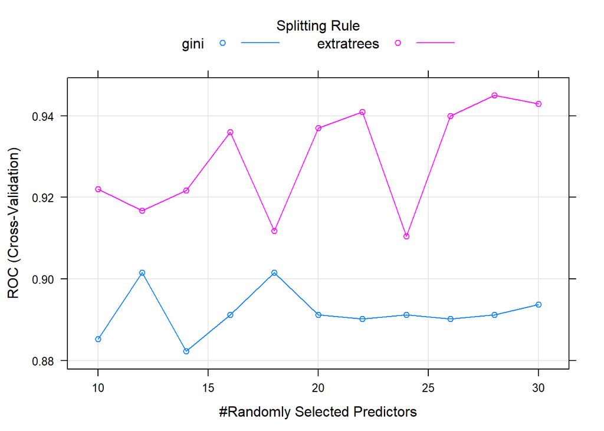

```r
plot(rf_fit1)
```

```r
rf_fit1$results[20,]
```

```
##    mtry  splitrule min.node.size   ROC Sens Spec      ROCSD    SensSD    SpecSD
## 20   28 extratrees             5 0.945 0.77 0.93 0.06059886 0.2573368 0.1636392
```

```r
preds <- predict(rf_fit1)
cf <- table(preds,musk3$y)
accuracy_rf = sum(diag(cf)/sum(cf))
cf
```

```
##
## preds No Yes
##   No  45   0
##   Yes  0  47
```

```r
accuracy_rf
```

```
## [1] 1
```

Random forest with second representation

```r
musk4$class <- ifelse(musk4$class==1, "Yes", "No")
setnames(musk4, "class", "y")

set.seed(1)
rf_fit2 <- caret::train(y ~ ., data = musk4,
                        method = "ranger", metric="ROC",
                        trControl = fitControl,
                        tuneGrid = rf_grid)
rf_fit2$bestTune
```

```
##    mtry  splitrule min.node.size
## 12   20 extratrees             5
```

```r
rf_fit2$results[12,]
```

```
##    mtry  splitrule min.node.size    ROC  Sens  Spec     ROCSD    SensSD    SpecSD
## 12   20 extratrees             5 0.7415 0.665 0.775 0.2886179 0.2135025 0.3048224
```

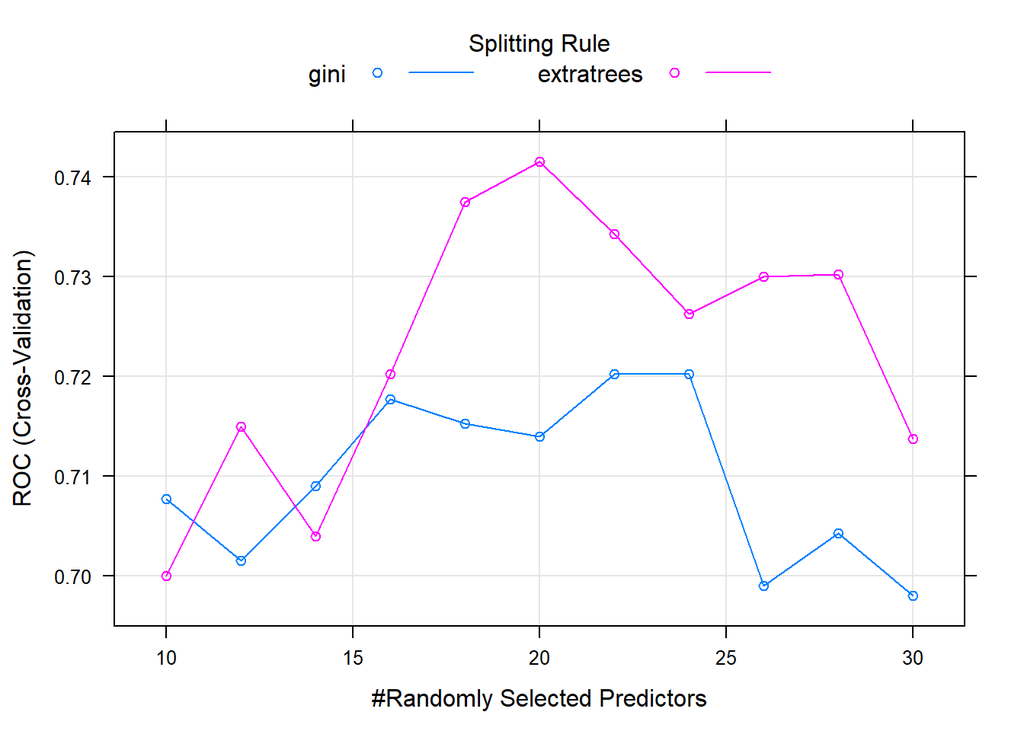

```r
plot(rf_fit2)
```

```r
preds <- predict(rf_fit2)
cf <- table(preds,musk4$y)
accuracy_rf = sum(diag(cf)/sum(cf))
print(cf)
```

```
##
## preds No Yes
##   No  45   0
##   Yes  0  47
```

```r
print(accuracy_rf)
```

```
## [1] 1
```

As last classifier. I will use gradient boosting. Gradient boosting with first representation

```r
gbmGrid <- expand.grid(interaction.depth = c(3, 4, 6, 8),
                       n.trees = c(1:5)*100,
                       shrinkage = seq(0.02, 0.1, 0.02),
                       n.minobsinnode = 5)
set.seed(1)
gbm_fit1 <- train(y ~ ., data = musk3,
                 method = "gbm",
                 trControl = fitControl, metric='ROC',
                 tuneGrid = gbmGrid,
                 verbose=F)

gbm_fit1$bestTune
```

```
##    n.trees interaction.depth shrinkage n.minobsinnode
## 90     500                 4       0.1              5
```

```r
gbm_fit1$results[90,]
```

```
##    shrinkage interaction.depth n.minobsinnode n.trees     ROC Sens  Spec      ROCSD    SensSD    SpecSD
## 90       0.1                 4              5     500 0.88525 0.76 0.865 0.07548409 0.1744834 0.1915579
```

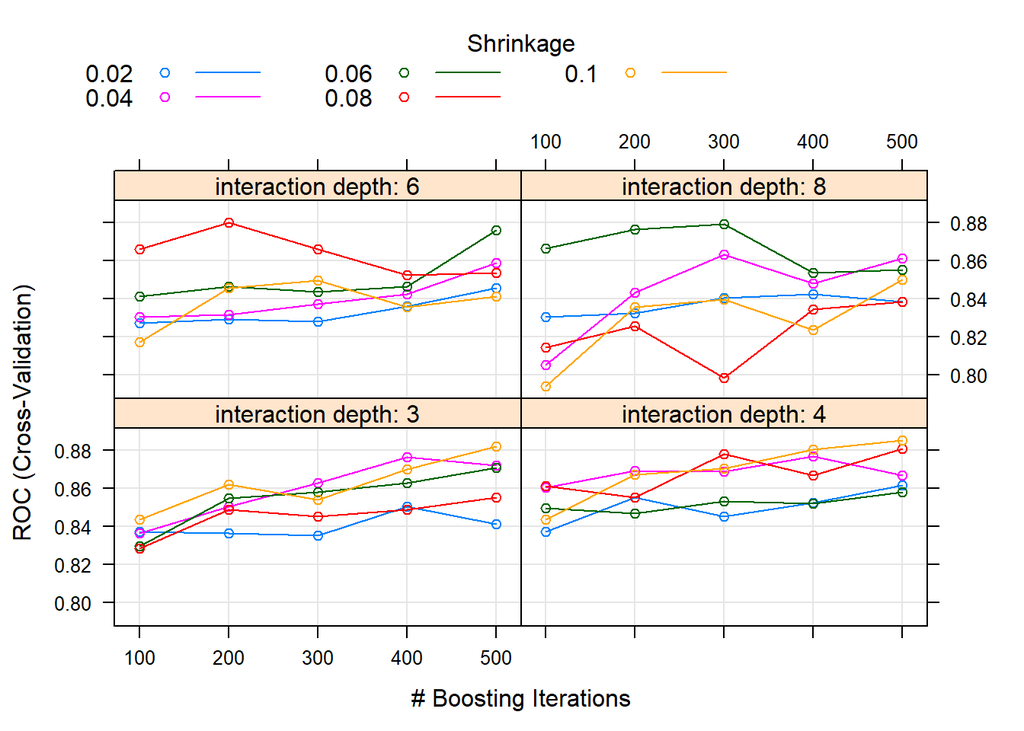

```r
plot(gbm_fit1)
```

```r
preds <- predict(gbm_fit1)
cf <- table(preds,musk3$y)
accuracy_rf = sum(diag(cf)/sum(cf))
print(cf)
```

```
##
## preds No Yes
##   No  45   0
##   Yes  0  47
```

```r
print(accuracy_rf)
```

```
## [1] 1
```

Gradient boosting with second representation

```r
set.seed(1)
gbm_fit2 <- train(y ~ ., data = musk4,
                  method = "gbm",
                  trControl = fitControl, metric='ROC',
                  tuneGrid = gbmGrid,
                  verbose=F)

gbm_fit2$bestTune
```

```
##    n.trees interaction.depth shrinkage n.minobsinnode
## 69     400                 4      0.08              5
```

```r
gbm_fit2$results[69,]
```

```
##    shrinkage interaction.depth n.minobsinnode n.trees   ROC Sens Spec    ROCSD    SensSD   SpecSD
## 69      0.08                 4              5     400 0.765 0.61 0.75 0.251981 0.2884826 0.317105
```

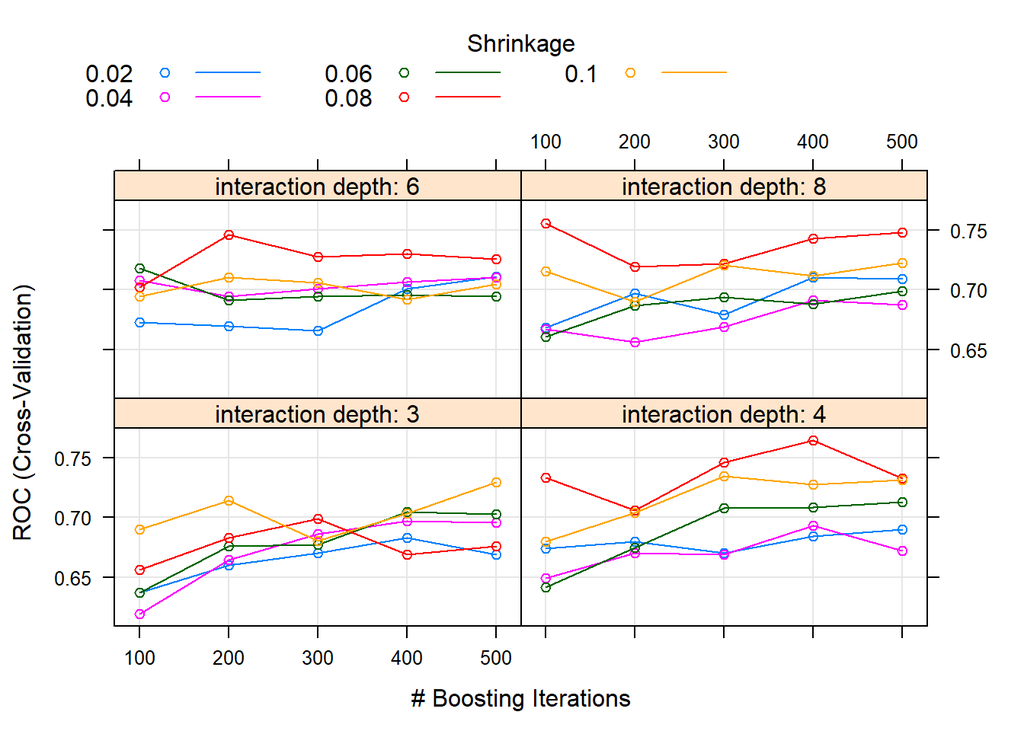

```r
plot(gbm_fit2)
```

```r
preds <- predict(gbm_fit2)
cf <- table(preds,musk4$y)
accuracy_rf = sum(diag(cf)/sum(cf))
print(cf)
```

```
##
## preds No Yes
##   No  45   0
##   Yes  0  47
```

```r
print(accuracy_rf)
```

```
## [1] 1
```